# Result

Gary Zhang

2022/7/28

# **IV. Results**

We measure each models ability on making out-of-sample predictions. We use 10 fold cross-validation to iterate through the 2021-2022 season of Premier League. Our accuracy is the measured by the mean of root mean squared error (RMSE) of the predicted expected goal difference per 90 minutes of each observation with the actual expected goal difference per 90 minutes within each fold.

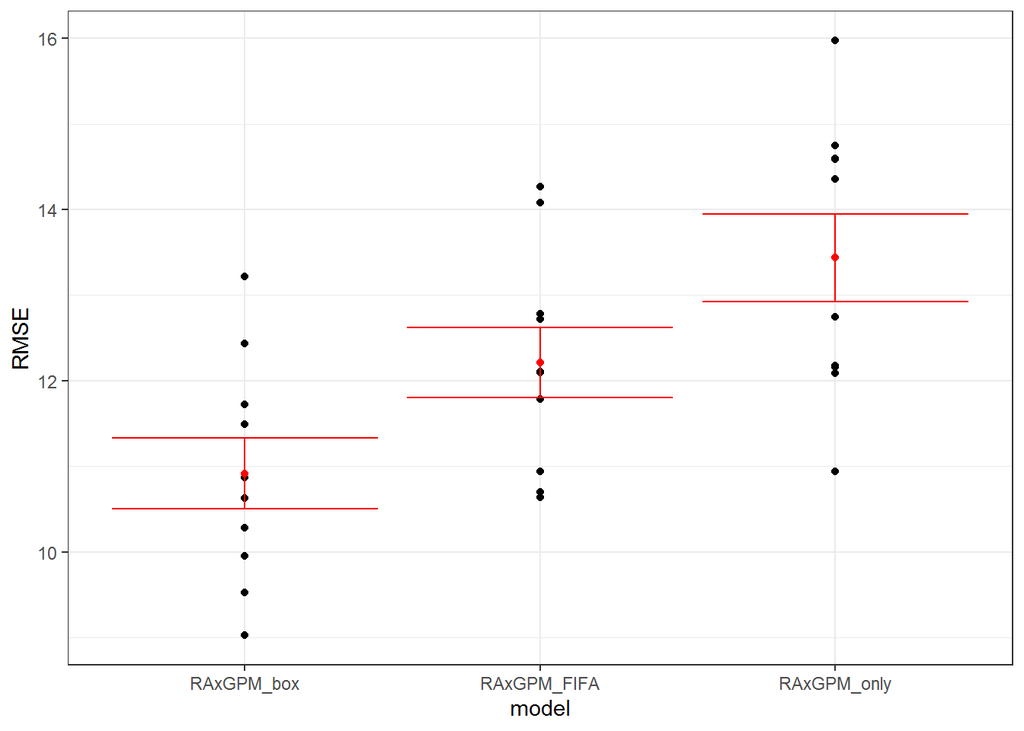

As shown in the figure above, the RAxGPM model with FIFA rating as prior improves on the RAxGPM model without any prior, which shows that having a prior is indeed adding valuable information to the model. Our RAxGPM model with prior created from box score has the best predictive accuracy, which shows that box score stats are more valuable as a predictor than FIFA rating.

Moreover, we are also interesting in if our model has more descriptive power on player’s evaluation. Regularized Adjusted Plus-Minus models are often validated by an “Intraocular” test, in that, it’s better if the results make intuitive sense to soccer fans.(Matano, 2018) Here, we expect that the box score prior we created are more descriptive on the player’s performance within a time period compare to FIFA rating.

| Player | Min | FIFA | FIFA_scaled | FIFA_coef | FIFA_rating |
| --- | --- | --- | --- | --- | --- |
| Cristiano Ronaldo | 2456 | 91 | 0.18337970 | -0.025928998 | 0.15745070 |
| Kevin De Bruyne | 2201 | 91 | 0.18337970 | -0.031216296 | 0.15216341 |
| N'Golo Kanté | 1773 | 90 | 0.16877140 | -0.016829795 | 0.15194160 |
| Harry Kane | 3232 | 90 | 0.16877140 | -0.021140864 | 0.14763053 |
| Son Heung-min | 3006 | 89 | 0.15416309 | -0.020227203 | 0.13393589 |
| Romelu Lukaku | 1589 | 88 | 0.13955478 | -0.010550486 | 0.12900430 |
| Mohamed Salah | 2762 | 89 | 0.15416309 | -0.032413974 | 0.12174911 |
| Sadio Mané | 2819 | 89 | 0.15416309 | -0.034628413 | 0.11953468 |
| Virgil van Dijk | 3060 | 89 | 0.15416309 | -0.039001020 | 0.11516207 |
| Alisson | 3240 | 89 | 0.15416309 | -0.040763611 | 0.11339948 |
| Raheem Sterling | 2128 | 88 | 0.13955478 | -0.029286060 | 0.11026872 |
| Paul Pogba | 1349 | 87 | 0.12494648 | -0.014734604 | 0.11021187 |
| Bruno Fernandes | 3111 | 88 | 0.13955478 | -0.029959630 | 0.10959515 |
| Ederson | 3330 | 89 | 0.15416309 | -0.045184422 | 0.10897867 |
| Jadon Sancho | 1900 | 87 | 0.12494648 | -0.019754643 | 0.10519183 |
| Hugo Lloris | 3420 | 87 | 0.12494648 | -0.021130534 | 0.10381594 |
| Jamie Vardy | 1806 | 86 | 0.11033817 | -0.007212952 | 0.10312522 |
| Pierre-Emerick Aubameyang | 1037 | 85 | 0.09572986 | 0.001241965 | 0.09697183 |
| Andrew Robertson | 2537 | 87 | 0.12494648 | -0.031461982 | 0.09348449 |
| Wilfred Ndidi | 1618 | 85 | 0.09572986 | -0.003712790 | 0.09201707 |

| Player | Min | Box | Box_scaled | box_coef | box_rating |
| --- | --- | --- | --- | --- | --- |
| Mohamed Salah | 2762 | 90.13389 | 0.17072737 | -0.020983221 | 0.14974414 |
| Reece James | 1864 | 87.35088 | 0.13007227 | -0.013206032 | 0.11686624 |
| İlkay Gündoğan | 1857 | 87.76583 | 0.13613392 | -0.021903192 | 0.11423073 |
| Sadio Mané | 2819 | 87.65664 | 0.13453885 | -0.022352605 | 0.11218625 |
| João Cancelo | 3227 | 88.39155 | 0.14527472 | -0.039079372 | 0.10619535 |
| Paul Pogba | 1349 | 86.09682 | 0.11175252 | -0.005673348 | 0.10607918 |
| Harry Kane | 3232 | 86.78122 | 0.12175045 | -0.017735882 | 0.10401457 |
| Son Heung-min | 3006 | 86.69345 | 0.12046826 | -0.016670782 | 0.10379748 |
| Alisson | 3240 | 87.27274 | 0.12893079 | -0.025960351 | 0.10297044 |
| Phil Foden | 2128 | 87.30791 | 0.12944459 | -0.026541067 | 0.10290352 |
| Ederson | 3330 | 88.14836 | 0.14172200 | -0.039339193 | 0.10238281 |
| Rúben Dias | 2402 | 87.23700 | 0.12840869 | -0.029164355 | 0.09924433 |
| Rodri | 2884 | 87.50666 | 0.13234799 | -0.034692487 | 0.09765550 |
| Roberto Firmino | 990 | 85.44965 | 0.10229855 | -0.007084858 | 0.09521369 |
| Gabriel Jesus | 1877 | 86.32616 | 0.11510281 | -0.020810223 | 0.09429259 |
| Raheem Sterling | 2128 | 86.64789 | 0.11980273 | -0.025900433 | 0.09390230 |
| Luis Díaz | 958 | 85.32550 | 0.10048491 | -0.007711580 | 0.09277333 |
| Kevin De Bruyne | 2201 | 86.60226 | 0.11913611 | -0.026656993 | 0.09247912 |
| Cristiano Ronaldo | 2456 | 85.19735 | 0.09861277 | -0.007373822 | 0.09123895 |
| Aymeric Laporte | 2828 | 86.94222 | 0.12410247 | -0.034799666 | 0.08930280 |

This is a good sign for the intraocular test.